# Final Project for Jour689R: Immigration and Topics Discussed in Baltimore News Articles and on Social Media (Spring 2025)

Breana Stevens

May 1, 2025

**Jour689R Spring 2025**

**Abstract:** This project looks at 81 news articles covering crime in Baltimore to understand the extent to which immigration is mentioned in those articles. It also uses 932 Reddit posts to understand the sentiments of posts and the topics discussed in a Baltimore group. I find that more than than a quarter of news articles mention immigration (28%). I also find that Reddit posts are generally neutral in nature and that users discussed topics related to community, the outdoors, and transportation, for example. The first portion of this project helps us understand how the news covers crime while the second portion allows us to undertand how the public talk about a city, with the future goal of narrowing that analysis to understand how they talk about crime as well. Future research could restrict the analysis of Reddit data to only posts that talk about crime to identify if there are parallel trends or frequencies in the extent to which immigration is discussed in each.

**Research Questions and Content Analysis Plans:**

**1. To what extent do news articles covering crime in Baltimore mention immigrant groups?**

**Data Source:** The data for this portion of the project consists of 100 newspaper articles downloaded from NexisUni. The articles were gathered based on the search parameters “crime” and “Baltimore”, meaning they had those two words in the article content. The data is restricted to those published in English. Once duplicated were identified, the data set yieled 81 articles.

**Summary of the literature:** Public discourse on crime has historically been and is increasingly racialized (Cho and Ho, 2018). For example, in national news, White people are more likely to be shown as crime victims, law enforcement, or bystanders (Adamson, 2016). In the context of immigration, one study found that from 1990 to 2013, “most immigration-crime news stories describe immigrants as especially crime-prone or as increasing aggregate crime rates” (Harris and Gruenewald, 2020).This is important because one way to ensure that an issue maintains prominence in public policy is through the use of media. This is because the public, especially voters, obtain their information about policies through the media. Recurring media coverage of a certain issue helps keep it at the forefront of the public’s mind. Additionally, political elites use the media to communicate their messages, including the policies that they are advocating for or against (Grossman, 2022). If media coverage consistlenty includes mentions of immigration in the context of crime, this could persuade voters to associate the two together and favor anti-immigration policies.

The city of Baltimore continues to publish news articles and data that suggests that crime in the city has decreased over time. Given this decline and media coverage of immigration-related crime, it is timely for this type of project.

[figure not shown]

Retrieved from: **[website]** (https://mayor.baltimorecity.gov/news/press-releases/2025-05-01-mayor-scott-highlights-continued-historic-decline)

**Content Analysis Plan:** The purpose of this is to understand the extent to which immigration is mentioned in crime articles covering Baltimore. I initially decided to classify articles containing the words immigrant, Mexican, Venezuelan, cartel, illegals, aliens, immigration in articles. Upon asking ChatGPT for additional descriptors that I had not identified on my own, I added the words migrant, refugee, asylum, border, documented, undocumented, deport, naturalization, sanctuary, detention, Central American, South American, Honduran, Guatemalan, Salvadoran, Latino, Hispanic, and South American that it gave me. I will quantify the number of articles that use this language to understand the extent to which these descriptors are used.

**2. How does the public use a social media site to discuss topics in Baltimore?**

**Data Source:** The data for this portion of the project consists of 932 Reddit posts made in the subreddit r/Baltimore. To ensure a wide range of posts are included in the data set, I made no restrictions on the types of posts selected. I pulled the data on May 1, 2025.

**Summary of the literature:** Group online platforms can serve the public in a number of ways, including serving as a community for similar or different types of people or serving as a form of media (Wilson and Peterson, 2002). Reddit forums dedicated to cities (such as r/baltimore) can serve as a place for past, present, or future residents/visitors to learn more about the city. However, there are also potential downsides to these online communities. In the context of cities or neighborhoods, residents have written posts where they racially profile other residents or warn their neighbors of African Americans, who they suspect may commit a crime, passing through the neighborhood (Lambright, 2019; Kurwa, 2019). In this way, online communities serve both positive and negative purposes for sharing information.

**Content Analysis Plan:** For the second research question, I will use the VADER lexicon as my codebook to identify understand sentiments in the group. The unit of analysis will be posts. Based on the lexicon, I will categorize articles within the sample as being mostly negative, neutral, or positive. I will then count the number of articles that fit into each category to better describe the data. I will also create a topic model to understand the categories of posts. This will help us understand how the public uses the subreddit and the extent to which certain topics are discussed.

```r
#Install packages if you don't have them already
# install.packages("tidyverse")
# install.packages("vader")
# install.packages("tidytext")
# install.packages("quanteda")
# install.packages("readtext")
# install.packages("DT")
# install.packages("rio")
# install.packages("lubridate")
```

```r
#Load the appropriate software libraries
library(tidyverse)
library(tidytext)
library(quanteda)
library(readtext)
library(DT)
library(lubridate)
library(rio)
library(dplyr)
library(vader)
library(scales)
library(ggplot2)
```

**Let’s start with the data needed for our first research question, “To what extent do news articles covering crime in Baltimore mention immigrant groups?”. Here, I am loading in our 81 articles covering crime in Baltimore, including the metadata.**

```r
#Import your data
bmore <- rio::import("Results list for__crime_ _Baltimore_ copy 2.XLSX")
bmore1 <- rio::import("Results list for__crime_ _Baltimore_(2).XLSX")
#Combining data files since the export gave me 2 files
bmore_final <- rbind(bmore, bmore1)

articles_df <- read_csv("articles_df copy 2.csv")
```

**It’s good to get to know your data first. Let’s check…how many articles are in our data set?**

```r
cat("\nNumber of articles: ", sum(!is.na(bmore_final$Title))  )
```

```
##
## Number of articles:  100
```

**What’s the average word count of the articles? Are they shorter or longer in nature?**

```r
# Convert Length to numeric (handles factors and characters)
bmore_final$Length <- as.numeric(as.character(bmore_final$Length))

# Now calculate the average word count
avg_word_count <- mean(bmore_final$Length, na.rm = TRUE)

cat("\nAverage word count seems to be medium in length. The average word count is:", round(avg_word_count, 2), "\n")
```

```
##
## Average word count seems to be medium in length. The average word count is: 780.77
```

```r
table(bmore_final$"Publication location")
```

```
##
##       Georgia      Illinois International      Maryland      New York
##             1             1            27            41             1
##  U.S. Federal     Wisconsin
##            28             1
```

**Let’s take a look at the distribution of the data over time. In which months did we see the most articles?**

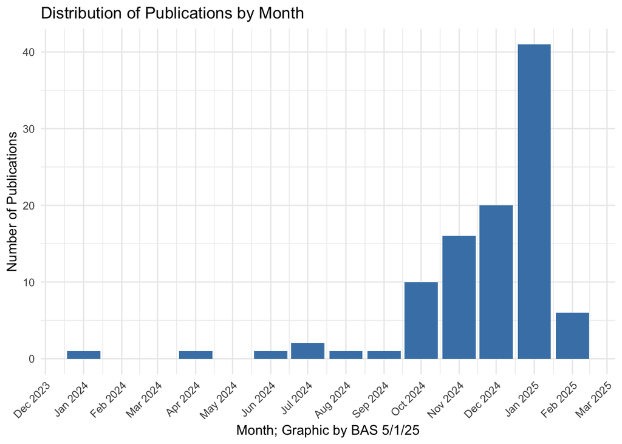

```r
#Let's extract the year, month, and day of the week from the data so that we can do this
bmore_final <- bmore_final %>%
  mutate(date_parsed = mdy(`Published date`),         # convert to actual Date
         year = year(date_parsed),                    # extract year
         month = month(date_parsed, label = TRUE),    # extract month (as label like Jan, Feb)
         day = day(date_parsed))                      # extract day


# Step 1: Create a new column with Year-Month format
bmore_final <- bmore_final %>%
  mutate(month_year = format(date_parsed, "%Y-%m"))  # or use lubridate::floor_date(date_parsed, "month")

# Step 2: Convert to factor or date for proper ordering
bmore_final$month_year <- as.Date(paste0(bmore_final$month_year, "-01"))  # ensures proper date order

# Step 3: Plot
ggplot(bmore_final, aes(x = month_year)) +
  geom_bar(fill = "steelblue") +
  labs(title = "Distribution of Publications by Month",
       x = "Month; Graphic by BAS 5/1/25",
       y = "Number of Publications") +
  scale_x_date(date_labels = "%b %Y", date_breaks = "1 month") +
  theme_minimal() +
  theme(axis.text.x = element_text(angle = 45, hjust = 1))
```

```r
# Step 1: Define the immigration-related keywords
keywords <- c("immigrant", "mexican", "venezuelan", "cartel", "illegals", "aliens", "immigration",
              "migrant", "refugee", "asylum", "border", "documented", "undocumented", "deport",
              "naturalization", "sanctuary", "detention", "central american", "south american",
              "honduran", "guatemalan", "salvadoran", "latino", "human trafficking", "slavery", "hispanic")

# Step 2: Create immigration flag at the sentence level, handling NA sentences
articles_df <- articles_df %>%
  mutate(
    sentence_clean = ifelse(is.na(sentence), "", tolower(sentence)),
    immigration = ifelse(str_detect(sentence_clean, str_c(keywords, collapse = "|")), 1, 0)
  )

# Step 3: Aggregate to article level (v1), ignoring NA values
article_flags <- articles_df %>%
  group_by(v1) %>%
  summarise(immigration_article = ifelse(sum(immigration, na.rm = TRUE) > 0, 1, 0))

# Step 4: Count how many articles mention immigration
immigration_count <- sum(article_flags$immigration_article, na.rm = TRUE)

# Output the result
print(paste("Number of articles mentioning immigration-related terms:", immigration_count))
```

```
## [1] "Number of articles mentioning immigration-related terms: 23"
```

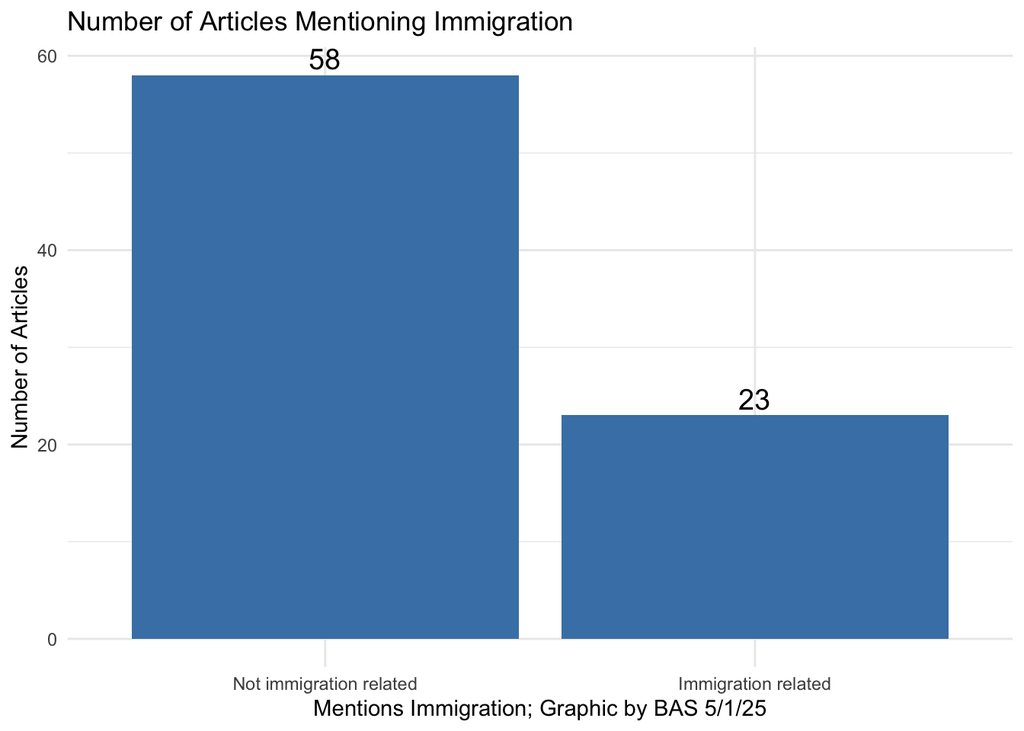

```r
# Create a summary data frame with counts
immigration_summary <- article_flags %>%
  count(immigration_article)

# Plot with customized x-axis labels
ggplot(immigration_summary, aes(x = factor(immigration_article), y = n)) +
  geom_bar(stat = "identity", fill = "steelblue") +
  geom_text(aes(label = n), vjust = -0.3, size = 5) +
  scale_x_discrete(
    labels = c("0" = "Not immigration related", "1" = "Immigration related")
  ) +
  labs(
    title = "Number of Articles Mentioning Immigration",
    x = "Mentions Immigration; Graphic by BAS 5/1/25",
    y = "Number of Articles"
  ) +
  theme_minimal()
```

**I found that 23 (or 28%) articles covering crime in Baltimore used immigration related words.**

**Now, let’s start on our second research question: How does the public use a social media site to discuss topics in Baltimore?**

```r
#Let's load any new libraries needed
#install.packages("devtools")
#devtools::install_github('ivan-rivera/RedditExtractor')
library(RedditExtractoR)
library(tidyverse)
```

```r
#Let's load our data!
#baltimore_urls <- find_thread_urls(subreddit="baltimore", sort_by="top")
#str(baltimore_urls)
#Remember, data changes throughout the day as more folks post on Reddit. So let's save our results and then import them so that we can work with the same data set. Let's also comment out the write.csv when done so that we don't overwrite.
#write.csv(baltimore_urls,"baltimore_urls.csv")
baltimore_urls = read.csv("baltimore_urls.csv")
```

**Let’s start with some bigrams to understand the top two-word phrases mentioned in these posts.**

```r
library(tidytext)
library(dplyr)

# Tokenize the 'text' column into individual words
baltimore_text_urls <- str_replace_all(baltimore_urls$text, "- ", "")
baltimore_text_urls <- tibble(baltimore_text_urls,)

# unnest includes lower, punct removal

stories_tokenized <- baltimore_text_urls %>%
  unnest_tokens(word,baltimore_text_urls)

stories_tokenized
```

```
## # A tibble: 53,055 × 1
##    word
##    <chr>
##  1 moving
##  2 to
##  3 baltimore
##  4 for
##  5 city
##  6 teaching
##  7 alliance
##  8 cohort
##  9 2025
## 10 any
## # ℹ 53,045 more rows
```

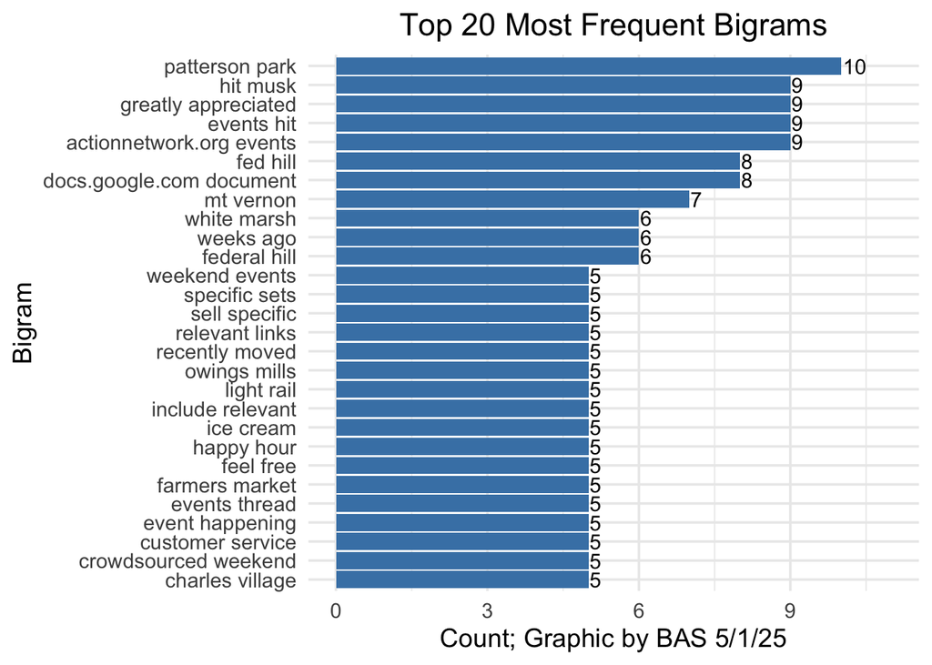

```r
data(stop_words)
stories_tokenized <- stories_tokenized %>%
  anti_join(stop_words, by = c("word" = "word")) %>%
  filter(word != "temp_file") %>%
  filter(word != "stories_corpus") %>%
  filter(!grepl('[0-9]', word))

bigrams <- baltimore_text_urls %>%
  unnest_tokens(bigram, baltimore_text_urls, token = "ngrams", n = 2)

#Filter out stop words.

bigrams1 <- bigrams %>%
  separate(bigram, c("word1", "word2"), sep = " ")

bigrams2 <- bigrams1 %>%
  filter(!word1 %in% stop_words$word) %>%
  filter(!word2 %in% stop_words$word) %>%
  filter(!word1 %in% c("amp", "jpg","format","width","https", "webp", "edit", "usp", "2025", "2", "baltimore", "15", "30")) %>%
  filter(!word2 %in% c("amp", "jpg","format","width","https","webp", "edit", "usp", "2025", "2", "baltimore", "15", "30")) %>%
  filter(!is.na(word1)) %>%
  filter(!is.na(word2))

# word count and top 20 bigram
bigram3 <- bigrams2 %>%
  count(word1, word2, sort = TRUE)%>%
  top_n(20, n)

library(dplyr)
library(ggplot2)
library(tidyr)

library(dplyr)
library(ggplot2)
library(tidyr)

# Step 1: Create bigram column from word1 and word2
bigram_plot_data <- bigram3 %>%
  unite("bigram", word1, word2, sep = " ") %>%
  arrange(desc(n)) %>%
  slice_max(n, n = 20)

# Step 2: Plot using the provided n column
ggplot(bigram_plot_data, aes(x = reorder(bigram, n), y = n)) +
  geom_col(fill = "steelblue") +
  geom_text(aes(label = n), hjust = -0.1, size = 4) +
  coord_flip() +
  labs(
    title = "Top 20 Most Frequent Bigrams",
    x = "Bigram",
    y = "Count; Graphic by BAS 5/1/25"
  ) +
  theme_minimal(base_size = 14) +
  theme(plot.title = element_text(hjust = 0.5)) +
  ylim(0, max(bigram_plot_data$n) * 1.1)  # gives space for labels
```

**The bigrams are interesting in that they reveal a bit about who is posting in this subreddit. There are numerous cities that show up in the bigrams, all of which are Baltimore’s more safe and predominantly White neighborhoods like Patterson Park, Federal Hill, and even White Marsh (which is in the county). This suggests that conversations (and possibly post originators) have ties to those neighborhoods. Further, bigrams related to events are pretty popular, which may be a result of spring and summer events popping up now that the weather is warmer.**

**Which posts (maybe the top 3) had the most number of comments? Let’s look at them…**

```r
options(tibble.width = Inf)  # Prevent text truncation

baltimore_urls %>%
  arrange(desc(comments)) %>%
  slice_head(n = 3) %>%
  select(title, text, comments)
```

```
##                                                                      title
## 1                                                        Why is this okay?
## 2                                               Why is Baltimore so trans?
## 3 Tell me about the worst meal you've sent back at a Baltimore restaurant.
##                                                                                                                                                                                                                                                                                                          …
## 1 Why is this okay? Essentially, every evening when it's nice out, a bunch of illegal dirt bikes gather at the base of Federal Hill... They then fly up and down the hill. Digging up the grass of the monument, and scare the crap out of tourists and other people with dogs and baby strollers. Often,…
## 2                                                                                                                                                                                                                                                                    Im trans, so of course I think this …
## 3                                                                                                                                                                                                                                                                                                        …
##   comments
## 1      622
## 2      329
## 3      318
```

**The first one is about the annoying dirt bikes that go through the Baltimore streets in the early and late afternoons. I feel their pain!** **The second is about Baltimore being (surprisingly) trans-friendly. That’s a good thing!** **The third is about sending back a meal at a Baltimore restaurant…okay?**

**Now, let’s do a sentiment analysis of these posts. What tones do they generally take on (positive, neutral, or negative)?** **This website has some great code for using VEDA: [website] (https://blog.marketingdatascience.ai/basic-sentiment-analysis-using-r-with-vader-4eecb738566f)**

```r
#Remember, we installed VADER earlier.
#install.packages("vader")
#library(vader)
vader_results <- baltimore_urls %>%
  mutate(vader_output = map(text, ~ get_vader(.x)))

#The code below characterizes each post by calculating the following:

#Word-level sentiment scores: Each word is assigned a sentiment score, adjusted based on factors like punctuation and capitalization.
#Compound score: A single value summarizing the overall sentiment of the entire sentence.
#Positive (pos), neutral (neu), and negative (neg) scores: Representing the percentage of words that fall into each sentiment category.
#But count: Tracks the occurrence of the word “but,” indicating potential shifts in sentiment within the sentence.

vader_results <- vader_results %>%
  mutate(
    word_scores = map(vader_output, ~ .x[names(.x) != "compound" &
                                           names(.x) != "pos" &
                                           names(.x) != "neu" &
                                           names(.x) != "neg" &
                                           names(.x) != "but_count"]),  # Extract word-level scores
    compound = map_dbl(vader_output, ~ as.numeric(.x["compound"])),
    pos = map_dbl(vader_output, ~ as.numeric(.x["pos"])),
    neu = map_dbl(vader_output, ~ as.numeric(.x["neu"])),
    neg = map_dbl(vader_output, ~ as.numeric(.x["neg"])),
    but_count = map_dbl(vader_output, ~ as.numeric(.x["but_count"]))
  )

#Now, let's visualize this.
# Count number of unique posts (based on text) with scores >= 0.5
neu_posts <- vader_results %>% filter(neu >= 0.5)
pos_posts <- vader_results %>% filter(pos >= 0.5)
neg_posts <- vader_results %>% filter(neg >= 0.5)

# Create summary table
high_score_counts <- data.frame(
  Sentiment = c("Neutral ≥ 0.5", "Positive ≥ 0.5", "Negative ≥ 0.5"),
  Count = c(
    n_distinct(neu_posts$text),
    n_distinct(pos_posts$text),
    n_distinct(neg_posts$text)
  )
)

# View result
print(high_score_counts)
```

```
##        Sentiment Count
## 1  Neutral ≥ 0.5   702
## 2 Positive ≥ 0.5     7
## 3 Negative ≥ 0.5     0
```

**Now, let’s visualize this.**

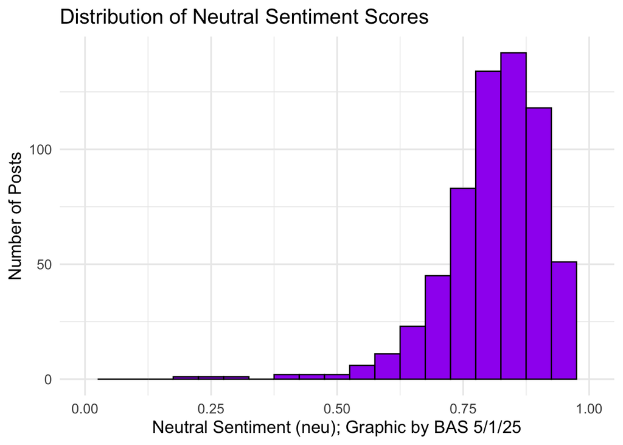

```r
ggplot(vader_results, aes(x = neu)) +
  geom_histogram(binwidth = 0.05, fill = "purple", color = "black") +
  scale_x_continuous(limits = c(0, 1)) +
  labs(
    title = "Distribution of Neutral Sentiment Scores",
    x = "Neutral Sentiment (neu); Graphic by BAS 5/1/25",
    y = "Number of Posts"
  ) +
  theme_minimal(base_size = 14)
```

**Interesting. Posts skew towards being neutral. This makes sense because it’s a lot of information sharing!**

**But let’s look at sentiments over time. Have they always been neutral?**

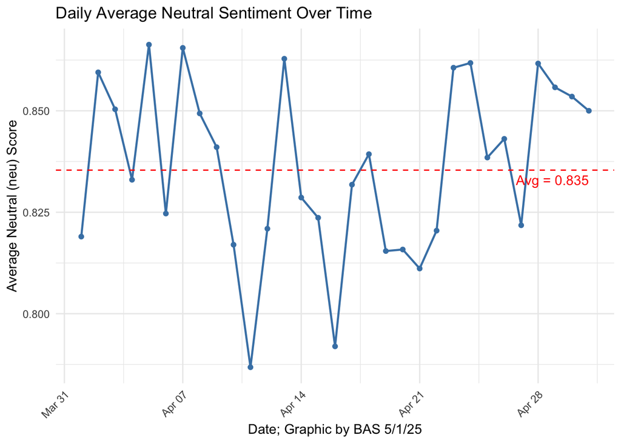

```r
#Note: I used ChatGPT for this portion because I wanted to add in an average line to understand how much posts deviated from the mean over time.

library(dplyr)
library(ggplot2)
library(lubridate)

# Step 1: Convert date_utc to Date if it's not already
vader_results <- vader_results %>%
  mutate(date_parsed = as.Date(date_utc))

# Step 2: Group by day and calculate average 'neu'
daily_neu <- vader_results %>%
  group_by(date_parsed) %>%
  summarise(avg_neu = mean(neu, na.rm = TRUE)) %>%
  ungroup()

# Step 3: Calculate overall average 'neu' across all posts
overall_avg_neu <- mean(vader_results$neu, na.rm = TRUE)

# Step 4: Plot the trend with average line
ggplot(daily_neu, aes(x = date_parsed, y = avg_neu)) +
  geom_line(color = "steelblue", size = 0.8) +
  geom_point(color = "steelblue", size = 1.5) +
  geom_hline(yintercept = overall_avg_neu, linetype = "dashed", color = "red") +
  labs(title = "Daily Average Neutral Sentiment Over Time",
       x = "Date; Graphic by BAS 5/1/25",
       y = "Average Neutral (neu) Score") +
  theme_minimal() +
  theme(axis.text.x = element_text(angle = 45, hjust = 1)) +
  annotate("text", x = max(daily_neu$date_parsed), y = overall_avg_neu, label = paste("Avg =", round(overall_avg_neu, 3)), color = "red", hjust = 1, vjust = 1.5)
```

**In general, posts are not deviating much from being neutral. Neutral scores remain above 0.7 no matter the day, suggesting that there is not a ton of variation.**

**And finally, let’s do some topic modeling. What are folks talking about? How do they use these groups?**

```r
# set options
options(stringsAsFactors = F)         # no automatic data transformation
options("scipen" = 100, "digits" = 4) # suppress math annotation
# load packages
here::here()
```

```
## [1] "/Users/breanastevens/Desktop/code/comp_text_class/Assignment 3"
```

```r
library(tidyverse)
library(tidytext)
library(rio)
library(readtext)
#topic modeling
library(quanteda)
library(tm)
library(topicmodels)
library(lda)
library(ldatuning)
# from tutorial packages
library(DT)
library(knitr)
library(kableExtra)
library(reshape2)
```

```r
library(ggplot2)
library(wordcloud)
library(pals)
library(SnowballC)
library(flextable)
### Process into corpus object
textdata <- baltimore_urls %>%
  select(title, text, date_utc, comments) %>%
  rename(doc_id = title) %>%
  as.data.frame()


# load stopwords
english_stopwords <- readLines("https://slcladal.github.io/resources/stopwords_en.txt", encoding = "UTF-8")


# create corpus object
corpus <- Corpus(DataframeSource(textdata))
# Preprocessing chain
processedCorpus <- tm_map(corpus, content_transformer(tolower))
processedCorpus <- tm_map(processedCorpus, removeWords, english_stopwords)
processedCorpus <- tm_map(processedCorpus, removePunctuation, preserve_intra_word_dashes = TRUE)
processedCorpus <- tm_map(processedCorpus, removeNumbers)
processedCorpus <- tm_map(processedCorpus, stemDocument, language = "en")
processedCorpus <- tm_map(processedCorpus, stripWhitespace)
```

```r
#DTM: rows correspond to the documents in the corpus. Columns correspond to the terms in the documents. Cells correspond to the weights of the terms. (Girder)
# compute document term matrix with terms >= minimumFrequency
minimumFrequency <- 5
DTM <- DocumentTermMatrix(processedCorpus, control = list(bounds = list(global = c(minimumFrequency, Inf))))
# have a look at the number of documents and terms in the matrix
dim(DTM)
```

```
## [1] 932 806
```

```r
# due to vocabulary pruning, we have empty rows in our DTM
# LDA does not like this. So we remove those docs from the
# DTM and the metadata
sel_idx <- slam::row_sums(DTM) > 0
DTM <- DTM[sel_idx, ]
textdata <- textdata[sel_idx, ]
#5 term minimum[1] 1387 3019
#5 term minimum[1] 308597 10339
```

```r
## Topic proportions over time {.unnumbered}

#We examine topics in the data over time by aggregating mean topic proportions per date These aggregated topic proportions can then be visualized, e.g. as a bar plot.
# append month information for aggregation
library(lubridate)
library(formattable)
textdata$date_parsed <- as.Date(textdata$date_utc)
textdata$day <- day(textdata$date_parsed)
```

```r
# number of topics
# K <- 20
K <- 6
# set random number generator seed
set.seed(9161)
#Latent Dirichlet Allocation, LDA, Gibbs is the sampling method
topicModel2 <- LDA(DTM, K, method="Gibbs", control=list(iter = 500, verbose = 25, alpha = 0.2))
```

```
## K = 6; V = 806; M = 708
## Sampling 500 iterations!
## Iteration 25 ...
## Iteration 50 ...
## Iteration 75 ...
## Iteration 100 ...
## Iteration 125 ...
## Iteration 150 ...
## Iteration 175 ...
## Iteration 200 ...
## Iteration 225 ...
## Iteration 250 ...
## Iteration 275 ...
## Iteration 300 ...
## Iteration 325 ...
## Iteration 350 ...
## Iteration 375 ...
## Iteration 400 ...
## Iteration 425 ...
## Iteration 450 ...
## Iteration 475 ...
## Iteration 500 ...
## Gibbs sampling completed!
```

```r
tmResult <- posterior(topicModel2)
theta <- tmResult$topics
beta <- tmResult$terms
topicNames <- apply(terms(topicModel2, 10), 2, paste, collapse = " ")  # reset topicnames
```

```r
### Mean topic proportions per day
# Step 1: Check dimensions
n_theta <- nrow(theta)
n_textdata <- length(textdata$day)

cat("Number of rows in theta: ", n_theta, "\n")
```

```
## Number of rows in theta:  708
```

```r
cat("Number of documents in textdata: ", n_textdata, "\n")
```

```
## Number of documents in textdata:  708
```

```r
# Check if textdata contains all the documents in theta
common_ids <- intersect(rownames(theta), textdata$doc_id) # Assuming textdata has a 'doc_id' column

# Filter textdata to include only the documents present in theta
textdata_filtered <- textdata[textdata$doc_id %in% common_ids, ]

# Check dimensions after filtering
n_textdata_filtered <- nrow(textdata_filtered)
cat("Number of documents in filtered textdata: ", n_textdata_filtered, "\n")
```

```
## Number of documents in filtered textdata:  708
```

```r
# Ensure the lengths match now
if (n_theta != n_textdata_filtered) {
  stop("The number of rows in 'theta' still does not match the length of 'textdata_filtered$decade'.")
}

# Align rownames of theta with filtered textdata
theta_aligned <- theta[rownames(theta) %in% textdata_filtered$doc_id, ]

# Optional: Verify the order of documents
if (!all(rownames(theta_aligned) == textdata_filtered$doc_id)) {
  # If the order doesn't match, reorder one to match the other
  textdata_filtered <- textdata_filtered[match(rownames(theta_aligned), textdata_filtered$doc_id), ]
}

# Ensure they are now aligned and can be combined
if (!all(rownames(theta_aligned) == textdata_filtered$doc_id)) {
  stop("The document IDs still do not match. Please check the data alignment.")
}

# Step 2: Combine data
topic_data <- data.frame(theta_aligned, day = textdata_filtered$day)

# Step 3: Aggregate data
topic_proportion_per_day <- aggregate(. ~ day, data = topic_data, FUN = mean)


# get mean topic proportions per month
# topic_proportion_per_month <- aggregate(theta, by = list(month = textdata$month), mean)
# set topic names to aggregated columns
colnames(topic_proportion_per_day)[2:(K+1)] <- topicNames
# reshape data frame
vizDataFrame <- melt(topic_proportion_per_day, id.vars = "day")
```

```r
# Step 1: Check dimensions
n_theta <- nrow(theta)
n_textdata <- length(textdata$date_utc)

cat("Number of rows in theta: ", n_theta, "\n")
```

```
## Number of rows in theta:  708
```

```r
cat("Number of documents in textdata: ", n_textdata, "\n")
```

```
## Number of documents in textdata:  708
```

```r
# Check if textdata contains all the documents in theta
common_ids <- intersect(rownames(theta), textdata$doc_id) # Assuming textdata has a 'doc_id' column

# Filter textdata to include only the documents present in theta
textdata_filtered <- textdata[textdata$doc_id %in% common_ids, ]

# Check dimensions after filtering
n_textdata_filtered <- nrow(textdata_filtered)
cat("Number of documents in filtered textdata: ", n_textdata_filtered, "\n")
```

```
## Number of documents in filtered textdata:  708
```

```r
# Ensure the lengths match now
if (n_theta != n_textdata_filtered) {
  stop("The number of rows in 'theta' still does not match the length of 'textdata_filtered$decade'.")
}

# Align rownames of theta with filtered textdata
theta_aligned <- theta[rownames(theta) %in% textdata_filtered$doc_id, ]

# Optional: Verify the order of documents
if (!all(rownames(theta_aligned) == textdata_filtered$doc_id)) {
  # If the order doesn't match, reorder one to match the other
  textdata_filtered <- textdata_filtered[match(rownames(theta_aligned), textdata_filtered$doc_id), ]
}

# Ensure they are now aligned and can be combined
if (!all(rownames(theta_aligned) == textdata_filtered$doc_id)) {
  stop("The document IDs still do not match. Please check the data alignment.")
}

# Step 2: Combine data
topic_data <- data.frame(theta_aligned, date = textdata_filtered$date_utc)

# Step 3: Aggregate data
topic_proportion_per_date <- aggregate(. ~ date, data = topic_data, FUN = mean)


# get mean topic proportions per month
# topic_proportion_per_month <- aggregate(theta, by = list(month = textdata$immigration), mean)
# set topic names to aggregated columns
colnames(topic_proportion_per_date)[2:(K+1)] <- topicNames
# reshape data frame
vizDataFrame <- melt(topic_proportion_per_date, id.vars = "date")
```

**Let’s examine topic names.**

```r
#enframe(): Converts a named list into a dataframe.
topics <- enframe(topicNames, name = "number", value = "text") %>%
  unnest(cols = c(text))

topics
```

```
## # A tibble: 6 × 2
##   number  text
##   <chr>   <chr>
## 1 Topic 1 "work year time pay month make week call back long"
## 2 Topic 2 "baltimor area citi move find recommend place live \u0019ve good"
## 3 Topic 3 "love place friend play food time game peopl bar open"
## 4 Topic 4 "baltimor local park citi communiti peopl amp book show free"
## 5 Topic 5 "park walk day hous pretti dog car citi area big"
## 6 Topic 6 "street train peopl baltimor event park light traffic weekend happen"
```

**Now, let’s review the topics and determine a 1-2 word label after reading the source documents.**

```r
#Topic 1    work year time pay month make week call back long

theta2 <- as.data.frame(theta)

topic1 <- theta2 %>%
  rownames_to_column(var = "file") |> # putting the rownames into a new column called file
  mutate(file = str_remove(file, "^X"),  # Remove leading 'X'
         line = str_extract(file, "(?<=\\.txt)\\.\\d+")) |>   # Extract number after .txt
  mutate(file = str_remove(file, "\\.\\d+$")) |>
  rename(topic1 = '1') |> # looking at first topic: work year time pay month make week call back long
  top_n(20, topic1) |>
  arrange(desc(topic1)) |>
  select(file, line, topic1)
```

```r
textdata <-textdata
```

```r
#add categories

vizDataFrame <- vizDataFrame %>%
  mutate(category = case_when(
    str_detect(variable,  "work year time pay month make week call back long") ~ "time and work",
    str_detect(variable, "baltimor area citi move find recommend place live \031ve good") ~ "recommendations",
    str_detect(variable, "love place friend play food time game peopl bar open") ~ "activities and friends",
    str_detect(variable, "baltimor local park citi communiti peopl amp book show free") ~ "community",
     str_detect(variable, "park walk day hous pretti dog car citi area big") ~ "outdoors",
    str_detect(variable, "street train peopl baltimor event park light traffic weekend happen") ~ "transportation",
    ))
```

```r
### for junk_words
theta2 <- as.data.frame(theta)

junk_words <- theta2 %>%
  #renaming for a general topic
  rename(junk_words = '4') %>%
  top_n(20, junk_words ) %>%
  arrange(desc(junk_words )) %>%
  select(junk_words)

# Apply rownames_to_column
junk_words  <- tibble::rownames_to_column(junk_words , "story_id")

junk_words $story_id <- gsub("X", "", junk_words $story_id)

head(junk_words$story_id, 20)
```

```
##  [1] "Exploring.how.better.waste.info.can.support.a.cleaner.Baltimore."
##  [2] "Alt.Art.Market.in.Station.North.this.Saturday.April.19th.12.5pm..hosted.by.Club.Car..Royal.Blue..Mobtown.Ballroom.and.Night.Owl.Gallery..Over.50.Vendors.in.four.locations..all.within.walking.distance"
##  [3] "Waverly.Commons.Concerts"
##  [4] "Are.there.any.local.businesses.in.Baltimore.that.offer.discounts.or.rewards.for.people.who.help.clean.up.the.city."
##  [5] "Baltimore.Farmers.Market.Asks.Reddit."
##  [6] "Fired.Federal.Workers.and.Federal.Grantees..Portrait.Photo.Story.Project"
##  [7] "Let.s.Go..TeslaTakedown.Owings.Mills..This.Saturday.Apr.26.11AM.12.30"
##  [8] "It.s.Earth.Day...Below.Are.5.Ways.to.Help.Keep.Baltimore.Beautiful..and.Weird."
##  [9] "A.Million.Lives.Book.Festival.Is.This.Weekend.at.the.Baltimore.Convention.Center."
## [10] ".Beyond.the.Frame....new.movie.club.at.Enoch.Pratt.Free.Library"
## [11] ".....Join.us.for.the.CommuterChoice.Maryland.Webinar..Employer.Spotlights...."
## [12] "Trump.administration.admits..error..in.deporting.Maryland.resident.to.El.Salvador"
## [13] "Seen.on.sparrows.point"
## [14] "BMORE.SCENE...A.new.networking.event.for.TV.and.Film.Creatives..Tue.Apr.22"
## [15] "Free.hobbies.m.classes."
## [16] "Stoop.Stories..Baltimore"
## [17] "Found.keys"
## [18] "The.Baltimore.Electronic.Collective.Presents..BEC.After.Dark"
## [19] "Looking.for.Norteña.classes"
## [20] "Rockers"
```

```r
#Checks out
```

**And let’s visualize what topics look like depending on the day of the week.**

[figure not shown]

```r
library(scales)
vizDataFrame$date <- as.Date(vizDataFrame$date)

#library(dplyr)
#ibrary(ggplot2)
#library(lubridate)

# Step 1: Add weekday column
vizDataFrame <- vizDataFrame %>%
  mutate(weekday = wday(date, label = TRUE, abbr = FALSE))  # Full day names like "Monday"

# Step 2: Normalize topic proportions by weekday
vizDataProportional <- vizDataFrame %>%
  group_by(weekday, category) %>%
  summarise(total_value = sum(value), .groups = "drop") %>%
  group_by(weekday) %>%
  mutate(proportion = total_value / sum(total_value))

# Step 3: Plot normalized (proportional) bar plot
ggplot(vizDataProportional, aes(x = weekday, y = proportion, fill = category)) +
  geom_bar(stat = "identity") +
  ylab("Proportion") +
  scale_fill_manual(
    values = c("#9933FF", "#33FFFF", "red", "yellow", "darkblue", "green"),
    name = "Topic"
  ) +
  theme_minimal(base_size = 14) +
  theme(axis.text.x = element_text(angle = 45, hjust = 1)) +
  labs(
    title = "Common Narratives in Baltimore Reddit",
    subtitle = "Six probable topics in sample. n = 932 posts",
    caption = "Topic proportions by weekday; Graphic by BAS 5/1/25"
  )
```

**Not so much time and work discussed on Saturday and Sundays. Also, more posts about the outdoors and recommendations during the middle of the week. This could be because folks are gearing up for things to do on the weekend?**

**Citations:** Adamson, Bryan. (2016). Thugs, Crooks, and Rebellious Negroes: Racist and Racialized Media Coverage of Michael Brown and the Ferguson Demonstrations. Harvard Journal on Racial & Ethnic Justice, 32, 189-278.

Cho, W. and Ho, A. (2018). Does neighborhood crime matter? A multiyear survey study on perceptions of race, victimization, and public safety. International Journal of Law, Crime and Justice, (55), 13-26.

Grossman, D. A. (2022). Media and policy making in the digital age. Routledge.

Harris, C.T. & Gruenewald, J. News Media Trends in the Framing of Immigration and Crime, 1990–2013, Social Problems, Volume 67, Issue 3, August 2020, Pages 452–470, https://doi.org/10.1093/socpro/spz024

Kurwa, R. (2019). Building the digitally gated community: The case of nextdoor. Surveillance and Society, 17(1), 111-117).

Lambright, K. (2019). Digital redlining: The Nextdoor app and the neighborhood of make-believe. Cultural Critique, 103, 84-90.